# EasyVisa Project

### 2. Bagging - Model Building and Hyperparameter Tuning

#### a. Bagging Classifier

```python
bagging = BaggingClassifier(random_state=1)
bagging.fit(X_train,y_train)
```

```
BaggingClassifier(random_state=1)
```

#### Checking model performance on training set

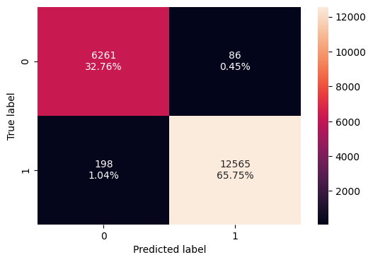

```python
confusion_matrix_sklearn(bagging, X_train, y_train)
```

```python
bagging_classifier_model_train_perf = model_performance_classification_sklearn(bagging, X_train, y_train)
bagging_classifier_model_train_perf
```

|  | Accuracy | Recall | Precision | F1 |
| --- | --- | --- | --- | --- |
| 0 | 0.985139 | 0.984486 | 0.993202 | 0.988825 |

*Observation*

- Model performance is very good across all metrics
- There is no underfitting

#### Checking model performance on testing set

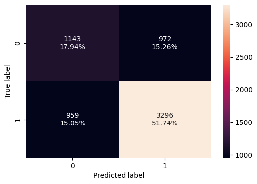

```python
confusion_matrix_sklearn(bagging, X_test, y_test)
```

```python
bagging_classifier_model_test_perf = model_performance_classification_sklearn(bagging, X_test, y_test)
bagging_classifier_model_test_perf
```

|  | Accuracy | Recall | Precision | F1 |
| --- | --- | --- | --- | --- |
| 0 | 0.69686 | 0.774618 | 0.772259 | 0.773437 |

*Observation*

- Model performance is fairly good
- However there is overfitting on all metrics

#### b. Hyperparameter Tuning - Bagging Classifier

```python
# Choose the type of classifier.
bagging_estimator_tuned = BaggingClassifier(random_state=1)

# Grid of parameters to choose from
parameters = {
    "max_samples": [0.7, 0.8],
    "max_features": [0.5,0.7,1],
    "n_estimators": np.arange(50,110,25),
}

# Type of scoring used to compare parameter combinations
acc_scorer = metrics.make_scorer(metrics.f1_score)

# Run the grid search
grid_obj = GridSearchCV(bagging_estimator_tuned, parameters, scoring=acc_scorer, cv=5)
grid_obj = grid_obj.fit(X_train, y_train)

# Set the clf to the best combination of parameters
bagging_estimator_tuned = grid_obj.best_estimator_

# Fit the best algorithm to the data.
bagging_estimator_tuned.fit(X_train, y_train)
```

```
BaggingClassifier(max_features=0.5, max_samples=0.7, n_estimators=75,
                  random_state=1)
```

#### Checking model performance on training set

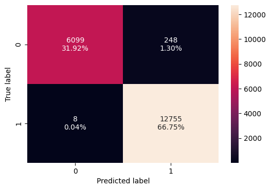

```python
confusion_matrix_sklearn(bagging_estimator_tuned, X_train, y_train)
```

```python
bagging_estimator_tuned_model_train_perf = model_performance_classification_sklearn(bagging_estimator_tuned, X_train, y_train) ## Complete the code to check performance for train data on tuned estimator
bagging_estimator_tuned_model_train_perf
```

|  | Accuracy | Recall | Precision | F1 |
| --- | --- | --- | --- | --- |
| 0 | 0.986604 | 0.999373 | 0.980927 | 0.990064 |

*Observation*

- Model performance is very good across all metrics
- There is no underfitting

#### Checking model performance on testing set

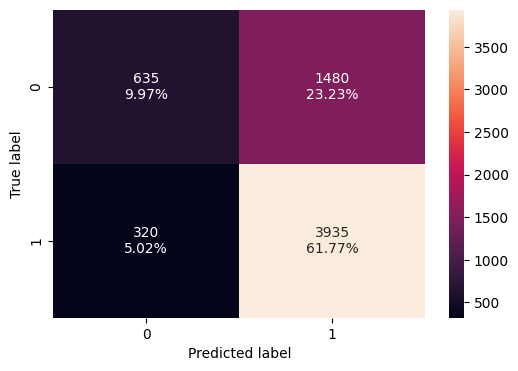

```python
confusion_matrix_sklearn(bagging_estimator_tuned, X_test, y_test)
```

```python
bagging_estimator_tuned_model_test_perf = model_performance_classification_sklearn(bagging_estimator_tuned, X_test, y_test)
bagging_estimator_tuned_model_test_perf
```

|  | Accuracy | Recall | Precision | F1 |
| --- | --- | --- | --- | --- |
| 0 | 0.717425 | 0.924794 | 0.726685 | 0.813857 |

*Observation*

### 3. Random Forest - Model Building and Hyperparameter Tuning

##### a. Random Forest

```python
rf = RandomForestClassifier(random_state=1, class_weight="balanced")
rf.fit(X_train,y_train)
```

```
RandomForestClassifier(class_weight='balanced', random_state=1)
```

#### Checking model performance on training set

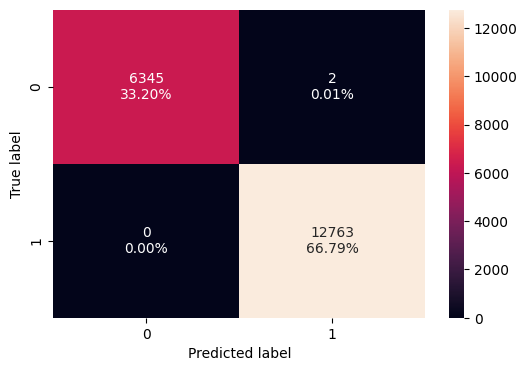

```python
confusion_matrix_sklearn(rf, X_train, y_train)
```

```python
# Calculating different metrics
rf_estimator_model_train_perf = model_performance_classification_sklearn(rf, X_train, y_train)
rf_estimator_model_train_perf
```

|  | Accuracy | Recall | Precision | F1 |
| --- | --- | --- | --- | --- |
| 0 | 0.999895 | 1.0 | 0.999843 | 0.999922 |

*Observation*

- The model is giving almost 100% performance on F1 score
- There is no underfitting

#### Checking model performance on test set

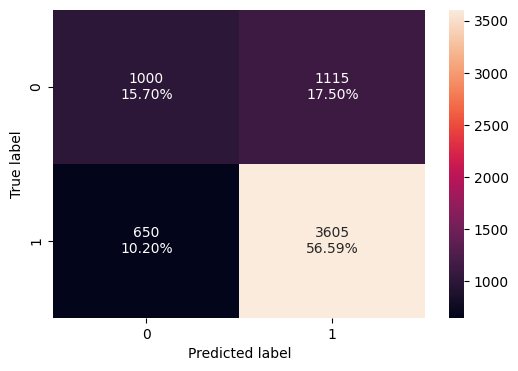

```python
confusion_matrix_sklearn(rf, X_test, y_test)
```

```python
rf_estimator_model_test_perf = model_performance_classification_sklearn(rf, X_test, y_test)
rf_estimator_model_test_perf
```

|  | Accuracy | Recall | Precision | F1 |
| --- | --- | --- | --- | --- |
| 0 | 0.72292 | 0.847239 | 0.763771 | 0.803343 |

*Observation*

- Model performance on test set is good.
- However there is overfitting

#### b. Hyperparameter Tuning - Random Forest

```python
# Choose the type of classifier.
rf_tuned = RandomForestClassifier(random_state=1, oob_score=True, bootstrap=True)

parameters = {
    "max_depth": list(np.arange(5, 15, 5)),
    "max_features": ["sqrt", "log2"],
    "min_samples_split": [3, 5, 7],
    "n_estimators": np.arange(10, 40, 10),
}

# Type of scoring used to compare parameter combinations
acc_scorer = metrics.make_scorer(metrics.f1_score)

# Run the grid search
grid_obj = GridSearchCV(rf_tuned, parameters, scoring=acc_scorer, cv=5)
grid_obj = grid_obj.fit(X_train, y_train)

# Set the clf to the best combination of parameters
rf_tuned = grid_obj.best_estimator_

# Fit the best algorithm to the data.
rf_tuned.fit(X_train, y_train)
```

```
RandomForestClassifier(max_depth=10, min_samples_split=5, n_estimators=30,
                       oob_score=True, random_state=1)
```

#### Checking model performance on training set

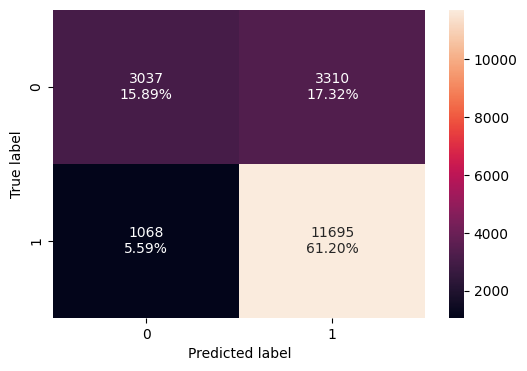

```python
confusion_matrix_sklearn(rf_tuned, X_train, y_train)
```

```python
rf_tuned_model_train_perf = model_performance_classification_sklearn(rf_tuned, X_train, y_train)
rf_tuned_model_train_perf
```

|  | Accuracy | Recall | Precision | F1 |
| --- | --- | --- | --- | --- |
| 0 | 0.770905 | 0.916321 | 0.779407 | 0.842337 |

*Observation*

- Model performance on F1 Score is good
- There is no underfittig
- However there is a huge difference between Recall and precision implying that the model is struggling in reducing False Positives. There is risk of certifying none deserving cases

#### Checking model performance on test set

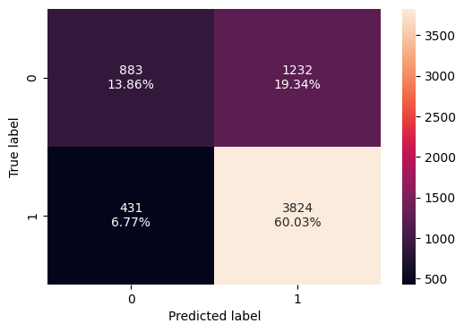

```python
confusion_matrix_sklearn(rf_tuned, X_test, y_test)
```

```python
rf_tuned_model_test_perf = model_performance_classification_sklearn(rf_tuned, X_test, y_test)
rf_tuned_model_test_perf
```

|  | Accuracy | Recall | Precision | F1 |
| --- | --- | --- | --- | --- |
| 0 | 0.738932 | 0.898707 | 0.756329 | 0.821394 |

*Observation*

- Model performance has dropped a little but is still good at 0.82 F1 Score
- There is no overfitting

### 4. Boosting - Model Building and Hyperparameter Tuning

### a. AdaBoost Classifier

```python
abc = AdaBoostClassifier(random_state=1)
abc.fit(X_train,y_train)
```

```
AdaBoostClassifier(random_state=1)
```

#### Checking model performance on training set

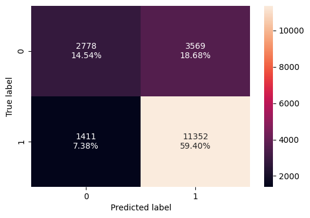

```python
confusion_matrix_sklearn(abc, X_train, y_train)
```

```python
ab_classifier_model_train_perf = model_performance_classification_sklearn(abc, X_train, y_train)
ab_classifier_model_train_perf
```

|  | Accuracy | Recall | Precision | F1 |
| --- | --- | --- | --- | --- |
| 0 | 0.739403 | 0.889446 | 0.760807 | 0.820113 |

*Observation*

- Model performance is good on training set at 0.82 F1 Score

#### Checking model performance on test set

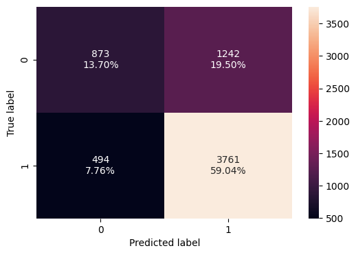

```python
confusion_matrix_sklearn(abc, X_test, y_test)
```

```python
ab_classifier_model_test_perf = model_performance_classification_sklearn(abc, X_test, y_test)
ab_classifier_model_test_perf
```

|  | Accuracy | Recall | Precision | F1 |
| --- | --- | --- | --- | --- |
| 0 | 0.727473 | 0.883901 | 0.751749 | 0.812486 |

*Observation*

- Model performance has slightly dropped but is still very good
- There is no overfitting

### b. Hyperparameter Tuning - AdaBoost Classifier

```python
# Choose the type of classifier.
abc_tuned = AdaBoostClassifier(random_state=1)

# Grid of parameters to choose from
parameters = {
    # Let's try different max_depth for base_estimator
    "base_estimator": [
        DecisionTreeClassifier(max_depth=2,random_state=1),
        DecisionTreeClassifier(max_depth=3,random_state=1),
    ],
    "n_estimators": np.arange(50,110,25),
    "learning_rate": np.arange(0.01,0.1,0.05),
}

# Type of scoring used to compare parameter  combinations
acc_scorer = metrics.make_scorer(metrics.f1_score)

# Run the grid search
grid_obj = GridSearchCV(abc_tuned, parameters, scoring=acc_scorer, cv=5)
grid_obj = grid_obj.fit(X_train, y_train)

# Set the clf to the best combination of parameters
abc_tuned = grid_obj.best_estimator_

# Fit the best algorithm to the data.
abc_tuned.fit(X_train, y_train)
```

```
AdaBoostClassifier(base_estimator=DecisionTreeClassifier(max_depth=3,
                                                         random_state=1),
                   learning_rate=0.060000000000000005, n_estimators=100,
                   random_state=1)
```

#### Checking model performance on training set

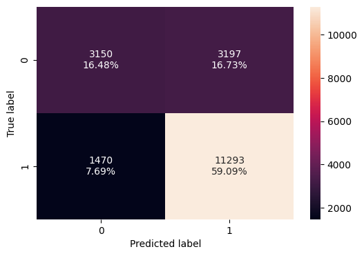

```python
confusion_matrix_sklearn(abc_tuned, X_train, y_train)
```

```python
abc_tuned_model_train_perf = model_performance_classification_sklearn(abc_tuned, X_train, y_train)
abc_tuned_model_train_perf
```

|  | Accuracy | Recall | Precision | F1 |
| --- | --- | --- | --- | --- |
| 0 | 0.755782 | 0.884823 | 0.779365 | 0.828753 |

*Observation*

- Model performance is very good at 0.83 F1 Score
- There is no underfitting

#### Checking model performance on test set

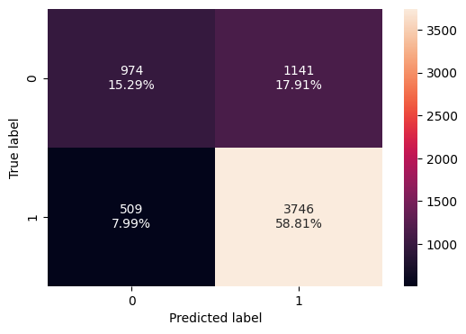

```python
confusion_matrix_sklearn(abc_tuned, X_test, y_test)
```

```python
abc_tuned_model_test_perf = model_performance_classification_sklearn(abc_tuned, X_test, y_test)
abc_tuned_model_test_perf
```

|  | Accuracy | Recall | Precision | F1 |
| --- | --- | --- | --- | --- |
| 0 | 0.740973 | 0.880376 | 0.766523 | 0.819514 |

*Observation*

- Model performance dropped slightly but is still very good at 0.81 F1 Score
- There is no overfitting

### c. Gradient Boosting Classifier

```python
gbc = GradientBoostingClassifier(random_state=1)
gbc.fit(X_train,y_train)
```

```
GradientBoostingClassifier(random_state=1)
```

#### Checking model performance on training set

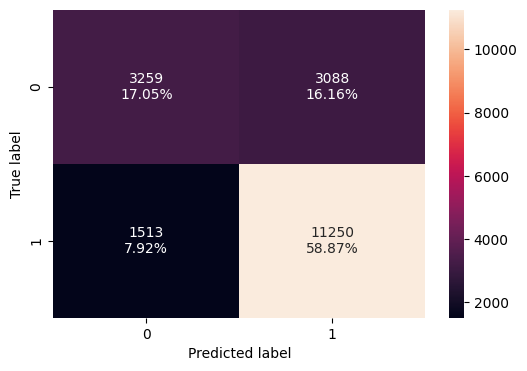

```python
confusion_matrix_sklearn(gbc, X_train, y_train)
```

```python
gb_classifier_model_train_perf = model_performance_classification_sklearn(gbc, X_train, y_train)
gb_classifier_model_train_perf
```

|  | Accuracy | Recall | Precision | F1 |
| --- | --- | --- | --- | --- |
| 0 | 0.759236 | 0.881454 | 0.784628 | 0.830228 |

*Observation*

- The model is performing well on training set with F1 Score of 0.83
- There is no underfitting

#### Checking model performance on test set

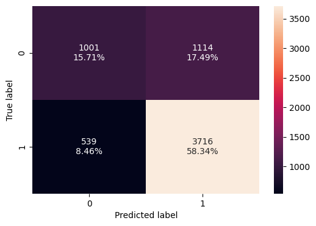

```python
confusion_matrix_sklearn(gbc, X_test, y_test)
```

```python
gb_classifier_model_test_perf = model_performance_classification_sklearn(gbc, X_test, y_test)
gb_classifier_model_test_perf
```

|  | Accuracy | Recall | Precision | F1 |
| --- | --- | --- | --- | --- |
| 0 | 0.740502 | 0.873325 | 0.769358 | 0.818052 |

*Observation*

- Model performance has dropped slightly but is still good with F1 Score of 0.81
- There is no overfitting

#### d. Hyperparameter Tuning - Gradient Boosting Classifier

```python
# Choose the type of classifier.
gbc_tuned = GradientBoostingClassifier(
    init=AdaBoostClassifier(random_state=1), random_state=1
)

# Grid of parameters to choose from
parameters = {
    "n_estimators": np.arange(50,110,25),
    "subsample": [0.7,0.9],
    "max_features": [0.7, 0.8, 0.9, 1],
    "learning_rate": [0.01,0.1,0.05],
}

# Type of scoring used to compare parameter combinations
acc_scorer = metrics.make_scorer(metrics.f1_score)

# Run the grid search
grid_obj = GridSearchCV(gbc_tuned, parameters, scoring=acc_scorer, cv=5)
grid_obj = grid_obj.fit(X_train, y_train)

# Set the clf to the best combination of parameters
gbc_tuned = grid_obj.best_estimator_

# Fit the best algorithm to the data.
gbc_tuned.fit(X_train, y_train)
```

```
GradientBoostingClassifier(init=AdaBoostClassifier(random_state=1),
                           learning_rate=0.05, max_features=0.8, random_state=1,
                           subsample=0.7)
```

#### Checking model performance on training set

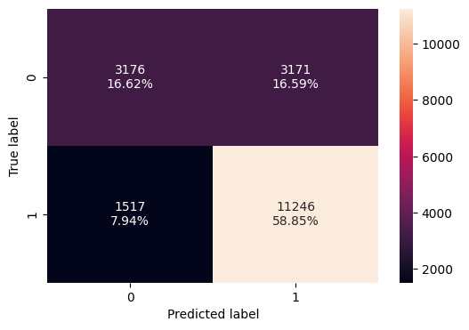

```python
confusion_matrix_sklearn(gbc_tuned, X_train, y_train)
```

```python
gbc_tuned_model_train_perf = model_performance_classification_sklearn(gbc_tuned, X_train, y_train)
gbc_tuned_model_train_perf
```

|  | Accuracy | Recall | Precision | F1 |
| --- | --- | --- | --- | --- |
| 0 | 0.754683 | 0.881141 | 0.780051 | 0.82752 |

*Observation*

- Model performance is good on the F1 Score at 0.83
- There is no underfitting

#### Checking model performance on test set

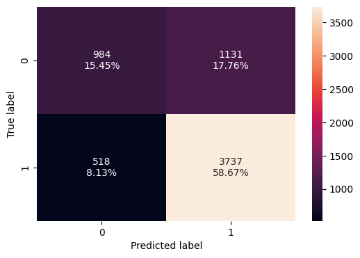

```python
confusion_matrix_sklearn(gbc_tuned, X_test, y_test)
```

```python
gbc_tuned_model_test_perf = model_performance_classification_sklearn(gbc_tuned, X_test, y_test)
gbc_tuned_model_test_perf
```

|  | Accuracy | Recall | Precision | F1 |
| --- | --- | --- | --- | --- |
| 0 | 0.74113 | 0.878261 | 0.767666 | 0.819248 |

*Observation*

- Model performance has slightly dropped but is equally good
- There is no overfitting

### e. XGBoost Classifier

```python
xgb = XGBClassifier(random_state=1,eval_metric='logloss')
xgb.fit(X_train,y_train)
```

```
XGBClassifier(base_score=None, booster=None, callbacks=None,
              colsample_bylevel=None, colsample_bynode=None,
              colsample_bytree=None, device=None, early_stopping_rounds=None,
              enable_categorical=False, eval_metric='logloss',
              feature_types=None, gamma=None, grow_policy=None,
              importance_type=None, interaction_constraints=None,
              learning_rate=None, max_bin=None, max_cat_threshold=None,
              max_cat_to_onehot=None, max_delta_step=None, max_depth=None,
              max_leaves=None, min_child_weight=None, missing=nan,
              monotone_constraints=None, multi_strategy=None, n_estimators=None,
              n_jobs=None, num_parallel_tree=None, random_state=1, ...)
```

#### Checking model performance on training set

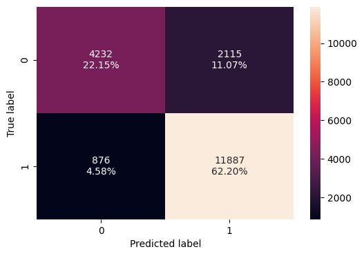

```python
confusion_matrix_sklearn(xgb, X_train, y_train)
```

```python
xgb_classifier_model_train_perf = model_performance_classification_sklearn(xgb, X_train,y_train)
xgb_classifier_model_train_perf
```

|  | Accuracy | Recall | Precision | F1 |
| --- | --- | --- | --- | --- |
| 0 | 0.843485 | 0.931364 | 0.84895 | 0.88825 |

*Observation*

- Model performance is very good at 0.89 F1 Score
- There is no underfitting

#### Checking model performance on test set

[figure not shown]

```python
confusion_matrix_sklearn(gbc_tuned, X_test, y_test)
```

```python
xgb_classifier_model_test_perf = model_performance_classification_sklearn(xgb, X_test, y_test)
xgb_classifier_model_test_perf
```

|  | Accuracy | Recall | Precision | F1 |
| --- | --- | --- | --- | --- |
| 0 | 0.729513 | 0.859224 | 0.764854 | 0.809297 |

*Observation*

#### f. Hyperparameter Tuning - XGBoost Classifier

```python
# Choose the type of classifier.
xgb_tuned = XGBClassifier(random_state=1, eval_metric="logloss")

# Grid of parameters to choose from
parameters = {
    "n_estimators": np.arange(50,110,25),
    "scale_pos_weight": [1,2,5],
    "subsample": [0.9, 1],
    "learning_rate": [0.01,0.1,0.05],
    "gamma": [1,3]
}

# Type of scoring used to compare parameter combinations
acc_scorer = metrics.make_scorer(metrics.f1_score)

# Run the grid search
grid_obj = GridSearchCV(xgb_tuned, parameters, scoring=acc_scorer, cv=5)
grid_obj = grid_obj.fit(X_train, y_train)

# Set the clf to the best combination of parameters
xgb_tuned = grid_obj.best_estimator_

# Fit the best algorithm to the data.
xgb_tuned.fit(X_train, y_train)
```

```
XGBClassifier(base_score=None, booster=None, callbacks=None,
              colsample_bylevel=None, colsample_bynode=None,
              colsample_bytree=None, device=None, early_stopping_rounds=None,
              enable_categorical=False, eval_metric='logloss',
              feature_types=None, gamma=1, grow_policy=None,
              importance_type=None, interaction_constraints=None,
              learning_rate=0.05, max_bin=None, max_cat_threshold=None,
              max_cat_to_onehot=None, max_delta_step=None, max_depth=None,
              max_leaves=None, min_child_weight=None, missing=nan,
              monotone_constraints=None, multi_strategy=None, n_estimators=50,
              n_jobs=None, num_parallel_tree=None, random_state=1, ...)
```

#### Checking model performance on training set

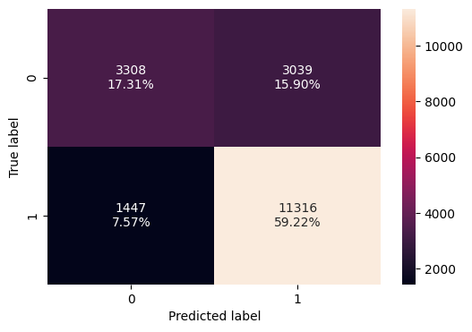

```python
confusion_matrix_sklearn(xgb_tuned, X_train, y_train)
```

```python
xgb_tuned_model_train_perf = model_performance_classification_sklearn(xgb_tuned, X_train, y_train)
xgb_tuned_model_train_perf
```

|  | Accuracy | Recall | Precision | F1 |
| --- | --- | --- | --- | --- |
| 0 | 0.765254 | 0.886625 | 0.788297 | 0.834575 |

*Observation*

- F1 Score is showing a very good performance at 0.83
- There is no underfitting

#### Checking model performance on test set

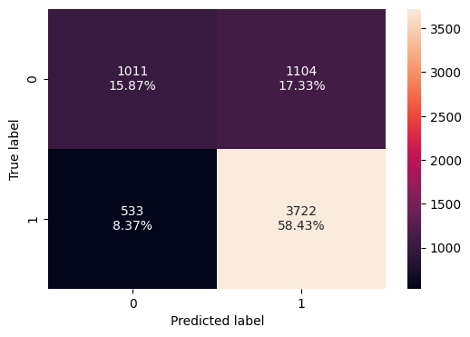

```python
confusion_matrix_sklearn(xgb_tuned, X_test, y_test)
```

```python
xgb_tuned_model_test_perf = model_performance_classification_sklearn(xgb_tuned, X_test, y_test)
xgb_tuned_model_test_perf
```

|  | Accuracy | Recall | Precision | F1 |
| --- | --- | --- | --- | --- |
| 0 | 0.743014 | 0.874736 | 0.771239 | 0.819734 |

*Observation*

- There is a slight drop in model performance on test set.
- However performance is still good at 0.82 F1 Score
- There is no overfitting

## Stacking Classifier

```python
estimators = [
    ("AdaBoost", abc_tuned),
    ("Gradient Boosting", gbc_tuned),
    ("Random Forest", rf_tuned),
]

final_estimator = xgb_tuned
```

```python
stacking_classifier = StackingClassifier(estimators=estimators, final_estimator=final_estimator, cv=5)

stacking_classifier.fit(X_train, y_train)
```

```
StackingClassifier(cv=5,
                   estimators=[('AdaBoost',
                                AdaBoostClassifier(base_estimator=DecisionTreeClassifier(max_depth=3,
                                                                                         random_state=1),
                                                   learning_rate=0.060000000000000005,
                                                   n_estimators=100,
                                                   random_state=1)),
                               ('Gradient Boosting',
                                GradientBoostingClassifier(init=AdaBoostClassifier(random_state=1),
                                                           learning_rate=0.05,
                                                           max_features=0.8,
                                                           random_state=1,
                                                           subsample=...
                                                 feature_types=None, gamma=1,
                                                 grow_policy=None,
                                                 importance_type=None,
                                                 interaction_constraints=None,
                                                 learning_rate=0.05,
                                                 max_bin=None,
                                                 max_cat_threshold=None,
                                                 max_cat_to_onehot=None,
                                                 max_delta_step=None,
                                                 max_depth=None,
                                                 max_leaves=None,
                                                 min_child_weight=None,
                                                 missing=nan,
                                                 monotone_constraints=None,
                                                 multi_strategy=None,
                                                 n_estimators=50, n_jobs=None,
                                                 num_parallel_tree=None,
                                                 random_state=1, ...))
```

### Checking model performance on training set

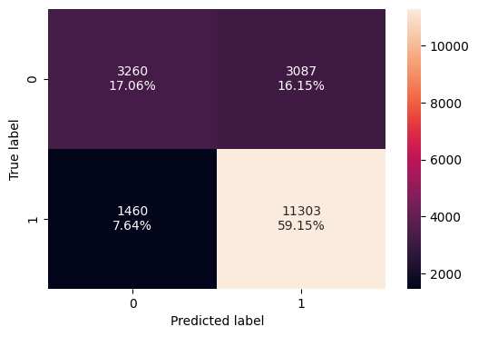

```python
confusion_matrix_sklearn(stacking_classifier, X_train, y_train)
```

```python
stacking_classifier_model_train_perf = model_performance_classification_sklearn(stacking_classifier, X_train, y_train)
stacking_classifier_model_train_perf
```

|  | Accuracy | Recall | Precision | F1 |
| --- | --- | --- | --- | --- |
| 0 | 0.762062 | 0.885607 | 0.785476 | 0.832542 |

*Observation*

- Model performance is very good but within same range as the estimators with F1 Score of 0.83
- There is no underfitting

### Checking model performance on test set

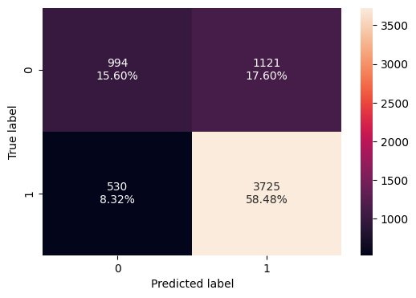

```python
confusion_matrix_sklearn(stacking_classifier, X_test, y_test)
```

```python
stacking_classifier_model_test_perf = model_performance_classification_sklearn(stacking_classifier, X_test, y_test)
stacking_classifier_model_test_perf
```

|  | Accuracy | Recall | Precision | F1 |
| --- | --- | --- | --- | --- |
| 0 | 0.740816 | 0.875441 | 0.768675 | 0.818591 |

*Observation*

- There is a slight drop in performance on the test set. So there is no overfitting
- Performance is still good at 0.82 on the F1 SCore

## Model Performance Comparison and Conclusions

```python
# training performance comparison

models_train_comp_df = pd.concat(
    [
        decision_tree_perf_train.T,
        dtree_estimator_model_train_perf.T,
        bagging_classifier_model_train_perf.T,
        bagging_estimator_tuned_model_train_perf.T,
        rf_estimator_model_train_perf.T,
        rf_tuned_model_train_perf.T,
        ab_classifier_model_train_perf.T,
        abc_tuned_model_train_perf.T,
        gb_classifier_model_train_perf.T,
        gbc_tuned_model_train_perf.T,
        xgb_classifier_model_train_perf.T,
        xgb_tuned_model_train_perf.T,
        stacking_classifier_model_train_perf.T,
    ],
    axis=1,
)
models_train_comp_df.columns = [
    "Decision Tree",
    "Tuned Decision Tree",
    "Bagging Classifier",
    "Tuned Bagging Classifier",
    "Random Forest",
    "Tuned Random Forest",
    "Adaboost Classifier",
    "Tuned Adaboost Classifier",
    "Gradient Boost Classifier",
    "Tuned Gradient Boost Classifier",
    "XGBoost Classifier",
    "XGBoost Classifier Tuned",
    "Stacking Classifier",
]
```

```python
# testing performance comparison

models_test_comp_df = pd.concat(
    [
        decision_tree_perf_test.T,
        dtree_estimator_model_test_perf.T,
        bagging_classifier_model_test_perf.T,
        bagging_estimator_tuned_model_test_perf.T,
        rf_estimator_model_test_perf.T,
        rf_tuned_model_test_perf.T,
        ab_classifier_model_test_perf.T,
        abc_tuned_model_test_perf.T,
        gb_classifier_model_test_perf.T,
        gbc_tuned_model_test_perf.T,
        xgb_classifier_model_test_perf.T,
        xgb_tuned_model_test_perf.T,
        stacking_classifier_model_test_perf.T,
    ],
    axis=1,
)
models_test_comp_df.columns = [
    "Decision Tree",
    "Tuned Decision Tree",
    "Bagging Classifier",
    "Tuned Bagging Classifier",
    "Random Forest",
    "Tuned Random Forest",
    "Adaboost Classifier",
    "Tuned Adaboost Classifier",
    "Gradient Boost Classifier",
    "Tuned Gradient Boost Classifier",
    "XGBoost Classifier",
    "XGBoost Classifier Tuned",
    "Stacking Classifier",
]
```

```python
print("Training performance comparison:")
models_train_comp_df
```

```
Training performance comparison:
```

|  | Decision Tree | Tuned Decision Tree | Bagging Classifier | Tuned Bagging Classifier | Random Forest | Tuned Random Forest | Adaboost Classifier | Tuned Adaboost Classifier | Gradient Boost Classifier | Tuned Gradient Boost Classifier | XGBoost Classifier | XGBoost Classifier Tuned | Stacking Classifier |
| --- | --- | --- | --- | --- | --- | --- | --- | --- | --- | --- | --- | --- | --- |
| Accuracy | 1.0 | 0.711983 | 0.985139 | 0.986604 | 0.999895 | 0.770905 | 0.739403 | 0.755782 | 0.759236 | 0.754683 | 0.843485 | 0.765254 | 0.762062 |
| Recall | 1.0 | 0.931599 | 0.984486 | 0.999373 | 1.000000 | 0.916321 | 0.889446 | 0.884823 | 0.881454 | 0.881141 | 0.931364 | 0.886625 | 0.885607 |
| Precision | 1.0 | 0.719690 | 0.993202 | 0.980927 | 0.999843 | 0.779407 | 0.760807 | 0.779365 | 0.784628 | 0.780051 | 0.848950 | 0.788297 | 0.785476 |
| F1 | 1.0 | 0.812048 | 0.988825 | 0.990064 | 0.999922 | 0.842337 | 0.820113 | 0.828753 | 0.830228 | 0.827520 | 0.888250 | 0.834575 | 0.832542 |

```python
print("Testing performance comparison:")
models_test_comp_df
```

```
Testing performance comparison:
```

|  | Decision Tree | Tuned Decision Tree | Bagging Classifier | Tuned Bagging Classifier | Random Forest | Tuned Random Forest | Adaboost Classifier | Tuned Adaboost Classifier | Gradient Boost Classifier | Tuned Gradient Boost Classifier | XGBoost Classifier | XGBoost Classifier Tuned | Stacking Classifier |
| --- | --- | --- | --- | --- | --- | --- | --- | --- | --- | --- | --- | --- | --- |
| Accuracy | 0.652433 | 0.707064 | 0.696860 | 0.717425 | 0.722920 | 0.738932 | 0.727473 | 0.740973 | 0.740502 | 0.741130 | 0.729513 | 0.743014 | 0.740816 |
| Recall | 0.736780 | 0.931610 | 0.774618 | 0.924794 | 0.847239 | 0.898707 | 0.883901 | 0.880376 | 0.873325 | 0.878261 | 0.859224 | 0.874736 | 0.875441 |
| Precision | 0.741310 | 0.715653 | 0.772259 | 0.726685 | 0.763771 | 0.756329 | 0.751749 | 0.766523 | 0.769358 | 0.767666 | 0.764854 | 0.771239 | 0.768675 |
| F1 | 0.739038 | 0.809475 | 0.773437 | 0.813857 | 0.803343 | 0.821394 | 0.812486 | 0.819514 | 0.818052 | 0.819248 | 0.809297 | 0.819734 | 0.818591 |

*Observation*

- The best Model is the Tuned Random Forest
- It has the highest F1 Score of 0.82
- It has also been observed that, except for Decision Tree and Bagging Classifier, Precision is much lower than recall. This means that these models struggle at correctly predicting denied cases

### Important features of the final model

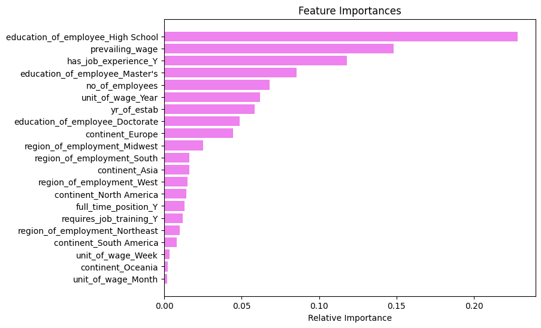

```python
feature_names = X_train.columns
importances = rf_tuned.feature_importances_
indices = np.argsort(importances)

plt.figure(figsize=(8, 6))
plt.title("Feature Importances")
plt.barh(range(len(indices)), importances[indices], color="violet", align="center")
plt.yticks(range(len(indices)), [feature_names[i] for i in indices])
plt.xlabel("Relative Importance")
plt.show()
```

*Observation*

- According to the final model, the most important features are education_of_employee_high_school, prevailing_wage, has_job_experience_y and education_of_employee_masters